# Lab0

Jas Sur

1/26/2022

# Lab 0 Problems

## Question 1.a

### Generate a random sample of 100 from t-distribtion, degree of freedom 10.

### Check qqnorm(); qqline(), Shapiro test. Remarks

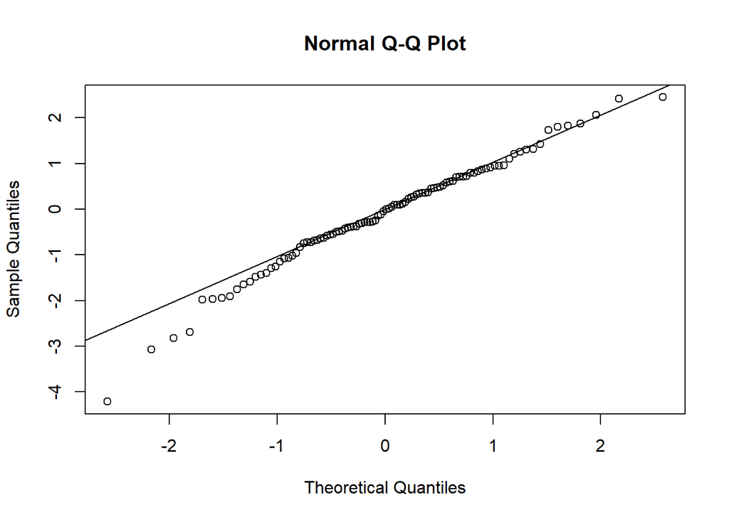

```r
sample.t <- rt(100, df=10)
qqnorm(sample.t)
qqline(sample.t)
```

```r
shapiro.test(sample.t)
```

```
##
##  Shapiro-Wilk normality test
##
## data:  sample.t
## W = 0.98004, p-value = 0.134
```

1. Null hypothesis (H0 sample data is normal)
2. Alternative hypothesis (H1 sample data is not normal)

Since the pvalue > 0.05, which means that the null hypothesis that values are normal is accepted and the alternative hypothesis is rejected. ***

## Question 1.b

### Generate a random sample of 100 from a Chi-square distribution, df =5.

### Perform same procedures as in (a) . Remarks.

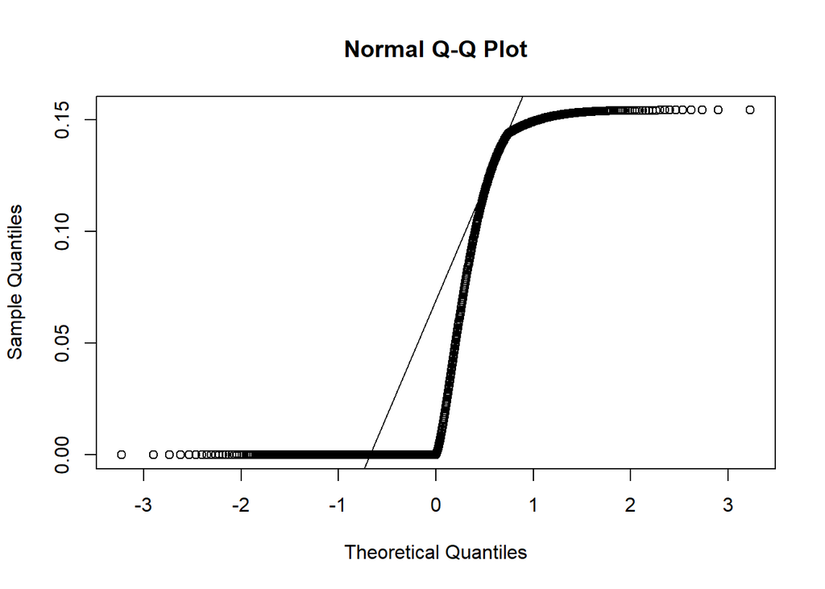

```r
sample.1b <-seq(-4, 4, 0.01)
sample.chi = dchisq(sample.1b, df=5)
qqnorm(sample.chi)
qqline(sample.chi)
```

```r
shapiro.test(sample.chi)
```

```
##
##  Shapiro-Wilk normality test
##
## data:  sample.chi
## W = 0.728, p-value < 2.2e-16
```

1. Null hypothesis (H0 sample data is normal)
2. Alternative hypothesis (H1 sample data is not normal)

Since the pvalue < 0.05, which means that the null hypothesis that values are normal is rejected and the alternative hypothesis is accepted.

## Question 2.a

### Write a 95%-CI for the population mean.

Confidence interval for population mean can be determined using the following

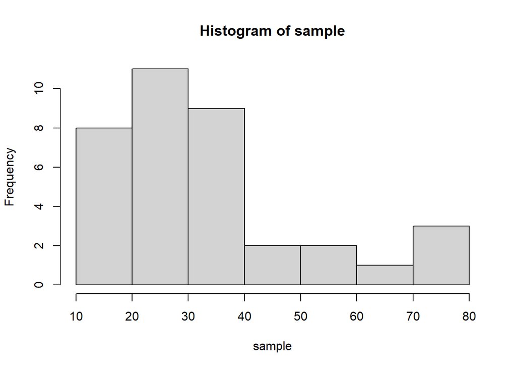

```r
sample <-c(26.4,23.5,25.4,22.9,25.2,39.2,25.5,31.9,26.0,44.6,35.5,38.6,
           30.1,31.0,30.8,32.8,47.7,39.1,55.3,50.7,73.8,71.1,68.4,77.1,
           19.4,19.3,18.7,19.0,23.2,21.3,23.2,19.9,18.9,19.8,19.6,21.9)
hist(sample)
```

```r
n<-length(sample)
xbar<-mean(sample)
s<-sd(sample)
sprintf("mean %f, std dev %f, sample size %d", xbar, s, n)
```

```
## [1] "mean 33.800000, std dev 16.897489, sample size 36"
```

```r
margin <- qt(0.95,df=n-1)*s/sqrt(n)
low_ci <- xbar - margin

high_ci <- xbar + margin
sprintf("confidence interval for the population mean is (%f, %f)", low_ci, high_ci)
```

```
## [1] "confidence interval for the population mean is (29.041745, 38.558255)"
```

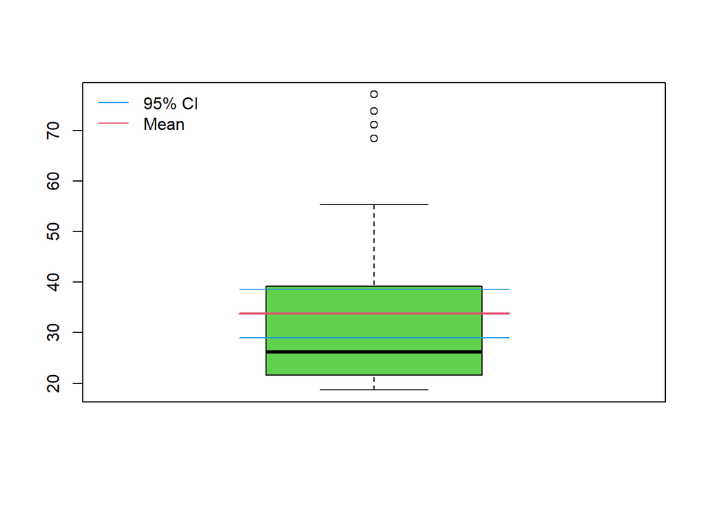

```r
boxplot(sample, col = 3)
lines(c(0.75,1.25),c(low_ci,low_ci),col=4)
lines(c(0.75,1.25),c(xbar,xbar),col=2,lwd=2)
lines(c(0.75,1.25),c(high_ci,high_ci),col=4)
legend("topleft", c("95% CI", "Mean"), lty=1,col = c(4, 2),bty ="n")
```

### What assumption about population for the work, suppose the sample is random.

The assumptions would be that the data is normal and the errors are constant.

## Question 2.b

### Write a 95%- CI for population standard deviation.

Confidence interval for population standard deviation can be determined using the following formula confidence interval: $CI = [√(n-1)s^{2}/X^{2}(α/2), √(n-1)s^{2}/ X^{2}(1-α/2)]$

```r
sample <-c(26.4,23.5,25.4,22.9,25.2,39.2,25.5,31.9,26.0,44.6,35.5,38.6,
           30.1,31.0,30.8,32.8,47.7,39.1,55.3,50.7,73.8,71.1,68.4,77.1,
           19.4,19.3,18.7,19.0,23.2,21.3,23.2,19.9,18.9,19.8,19.6,21.9)
n <- length(sample)
xbar<-mean(sample)
s<-sd(sample)
sprintf("population sd %f, size %d, mean %f", s, n, xbar)
```

```
## [1] "population sd 16.897489, size 36, mean 33.800000"
```

```r
left <- qchisq(p=.05, df=n-1, lower.tail=FALSE)
right <- qchisq(p=.95, df=n-1, lower.tail=FALSE)
low_ci <- sqrt((n-1)*s^2/left)
high_ci <- sqrt((n-1)*s^2/right)

sprintf("Confidence interval for population std dev is  %f, %f", low_ci, high_ci)
```

```
## [1] "Confidence interval for population std dev is  14.165551, 21.091275"
```

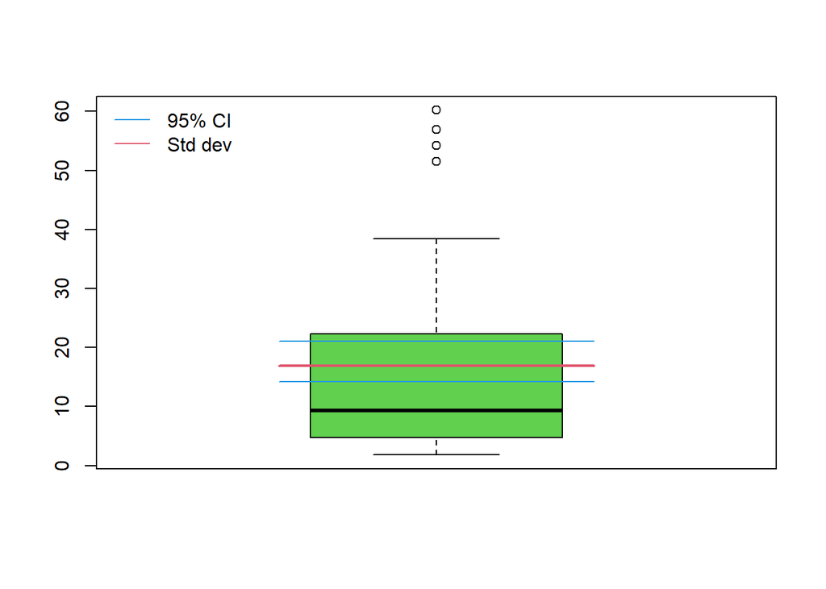

```r
boxplot(sample-s, col = 3)
lines(c(0.75,1.25),c(low_ci,low_ci),col=4)
lines(c(0.75,1.25),c(s,s),col=2,lwd=2)
lines(c(0.75,1.25),c(high_ci,high_ci),col=4)
legend("topleft", c("95% CI", "Std dev"), lty=1,col = c(4, 2),bty ="n")
```

*A confidence interval for a standard deviation is a range of values that is likely to contain true population standard deviation with a certain level of confidence.*

# Question 3

### Run the following code

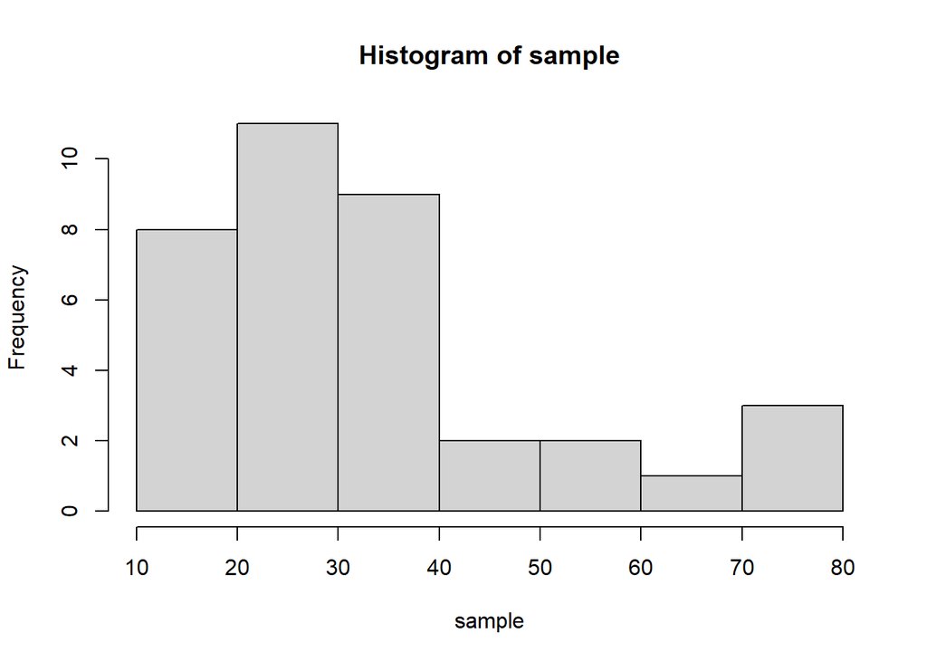

```r
sample <-c(26.4,23.5,25.4,22.9,25.2,39.2,25.5,31.9,26.0,44.6,35.5,38.6,
           30.1,31.0,30.8,32.8,47.7,39.1,55.3,50.7,73.8,71.1,68.4,77.1,
           19.4,19.3,18.7,19.0,23.2,21.3,23.2,19.9,18.9,19.8,19.6,21.9)
hist(sample)
```

```r
sample.s <-sort(sample) #sort data increasing
rank <- rank(sample.s) #rank data from 1 to 36
size <- length(sample.s) # size of data
p <- (rank-.5)/size #cummulative prob of data
z.quantile <- qnorm(p) # Standard Normal quantiles with such probability

data <- cbind(rank, sample.s, p, z.quantile)
data
```

```
##       rank sample.s          p  z.quantile
##  [1,]  1.0     18.7 0.01388889 -2.20041058
##  [2,]  2.0     18.9 0.04166667 -1.73166440
##  [3,]  3.0     19.0 0.06944444 -1.47994139
##  [4,]  4.0     19.3 0.09722222 -1.29754293
##  [5,]  5.0     19.4 0.12500000 -1.15034938
##  [6,]  6.0     19.6 0.15277778 -1.02459239
##  [7,]  7.0     19.8 0.18055556 -0.91324993
##  [8,]  8.0     19.9 0.20833333 -0.81221780
##  [9,]  9.0     21.3 0.23611111 -0.71886805
## [10,] 10.0     21.9 0.26388889 -0.63140189
## [11,] 11.0     22.9 0.29166667 -0.54852228
## [12,] 12.5     23.2 0.33333333 -0.43072730
## [13,] 12.5     23.2 0.33333333 -0.43072730
## [14,] 14.0     23.5 0.37500000 -0.31863936
```

[output cut: 22 more lines]

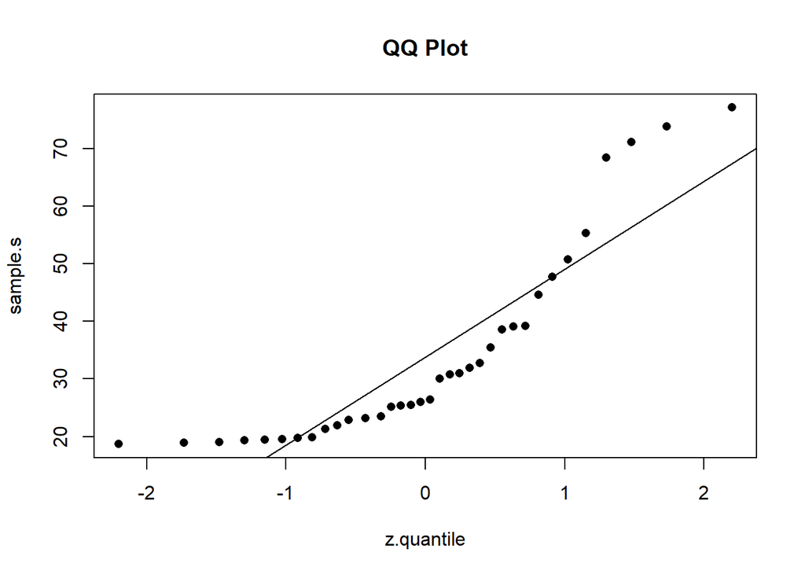

```r
#scatterplot of x=Z quantiles, y= data sorted
plot(x=z.quantile, y=sample.s, pch=16, main="QQ Plot")
abline(lm(sample.s ~ z.quantile))
```

The QQ plot suggests that the data is not normal